# Exercise 4.16

Kári Hlynsson

2024-01-21

Using the Boston data set, fit classification models in order to predict whether a given census tract has a crime rate above or below the median. Explore logistic regression, LDA, naive Bayes, and KNN models using various subsets of the predictors. Describe your findings.

*Hint: You will have to create the response variable yourself, using the variables that are contained in the Boston data set.*

```r
library(ISLR2)

data(Boston)
attach(Boston)
```

Start by creating the response variable. We will convert it to a factor at a later time.

```r
Boston$crim01 <- ifelse(crim > median(crim), 1, 0)
```

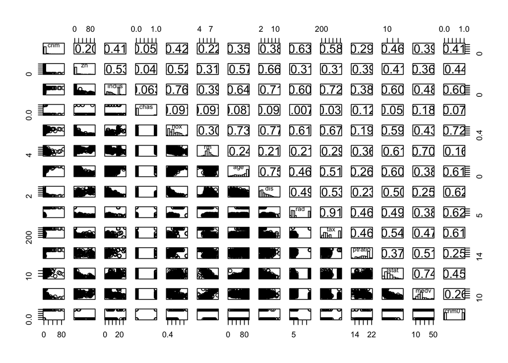

```r
pair_plot(Boston)
```

Let’s get our hands dirty! Figure out which predictors are most correlated with the response:

```r
cor_mat <- cor(Boston)
crim_vec <- cor_mat[2:13,14]

crim_vec[order(abs(crim_vec), decreasing = TRUE)]
```

```
##         nox         rad         dis         age         tax       indus
##  0.72323480  0.61978625 -0.61634164  0.61393992  0.60874128  0.60326017
##       lstat          zn        medv     ptratio          rm        chas
##  0.45326273 -0.43615103 -0.26301673  0.25356836 -0.15637178  0.07009677
```

They are ($\rho > 0.5$)

## Train / test split

Split the data immediately into training / test splits for validation of model accuracy. I will use 75% of the data for training:

```r
set.seed(1)

n <- nrow(Boston)
sel <- sample(1:n, round(0.75 * n))

train <- Boston[sel, ]
train.X <- train[,2:13]
train.Y <- train[,14]

test <- Boston[setdiff(1:n, sel), ]
test.X <- test[,2:13]
test.Y <- test[,14]
```

## Logistic Regression

```r
glm.fit <- glm(crim01 ~ . - crim, family = "binomial", data = train)
summary(glm.fit)
```

```
##
## Call:
## glm(formula = crim01 ~ . - crim, family = "binomial", data = train)
##
## Coefficients:
##               Estimate Std. Error z value Pr(>|z|)
## (Intercept) -47.886748   7.753852  -6.176 6.58e-10 ***
## zn           -0.116496   0.046577  -2.501 0.012380 *
## indus        -0.085328   0.054958  -1.553 0.120516
## chas          0.113519   0.799002   0.142 0.887020
## nox          59.921922  10.147135   5.905 3.52e-09 ***
## rm           -0.313731   0.856356  -0.366 0.714100
## age           0.027190   0.014223   1.912 0.055923 .
## dis           1.237486   0.302922   4.085 4.40e-05 ***
## rad           0.647500   0.179811   3.601 0.000317 ***
## tax          -0.005978   0.003080  -1.941 0.052265 .
## ptratio       0.281874   0.146473   1.924 0.054304 .
## lstat         0.115460   0.056515   2.043 0.041051 *
## medv          0.195726   0.083966   2.331 0.019753 *
## ---
## Signif. codes:  0 '***' 0.001 '**' 0.01 '*' 0.05 '.' 0.1 ' ' 1
##
## (Dispersion parameter for binomial family taken to be 1)
##
##     Null deviance: 526.78  on 379  degrees of freedom
## Residual deviance: 151.09  on 367  degrees of freedom
## AIC: 177.09
##
## Number of Fisher Scoring iterations: 9
```

Find the optimal model using stepwise regression to get an idea of what subset of predictors is best:

```r
glm.fit <- stepAIC(glm.fit)
```

```
## Start:  AIC=177.09
## crim01 ~ (crim + zn + indus + chas + nox + rm + age + dis + rad +
##     tax + ptratio + lstat + medv) - crim
##
##           Df Deviance    AIC
## - chas     1   151.11 175.11
## - rm       1   151.22 175.22
## <none>         151.09 177.09
## - indus    1   153.68 177.68
## - age      1   154.96 178.96
## - ptratio  1   155.05 179.05
## - tax      1   155.23 179.23
## - lstat    1   155.33 179.33
## - medv     1   157.13 181.13
## - zn       1   160.95 184.95
## - dis      1   172.56 196.56
## - rad      1   188.07 212.07
## - nox      1   224.32 248.32
##
## Step:  AIC=175.11
## crim01 ~ zn + indus + nox + rm + age + dis + rad + tax + ptratio +
##     lstat + medv
##
##           Df Deviance    AIC
## - rm       1   151.24 173.24
## <none>         151.11 175.11
## - indus    1   153.71 175.71
## - age      1   155.14 177.14
## - ptratio  1   155.15 177.15
## - lstat    1   155.44 177.44
## - tax      1   155.51 177.51
## - medv     1   157.16 179.16
## - zn       1   161.47 183.47
## - dis      1   172.61 194.61
## - rad      1   190.25 212.25
## - nox      1   225.07 247.07
##
## Step:  AIC=173.24
## crim01 ~ zn + indus + nox + age + dis + rad + tax + ptratio +
##     lstat + medv
##
##           Df Deviance    AIC
## <none>         151.24 173.24
## - indus    1   153.76 173.76
## - ptratio  1   155.33 175.33
## - age      1   155.54 175.54
## - tax      1   155.94 175.94
## - lstat    1   156.31 176.31
## - zn       1   161.75 181.75
## - medv     1   166.76 186.76
## - dis      1   172.80 192.80
## - rad      1   190.29 210.29
## - nox      1   225.57 245.57
```

```r
summary(glm.fit)
```

```
##
## Call:
## glm(formula = crim01 ~ zn + indus + nox + age + dis + rad + tax +
##     ptratio + lstat + medv, family = "binomial", data = train)
##
## Coefficients:
##               Estimate Std. Error z value Pr(>|z|)
## (Intercept) -48.226955   7.587092  -6.356 2.06e-10 ***
## zn           -0.118114   0.045684  -2.585 0.009725 **
## indus        -0.082537   0.053931  -1.530 0.125916
## nox          59.180761   9.890643   5.984 2.18e-09 ***
## age           0.025152   0.012565   2.002 0.045306 *
## dis           1.213648   0.293110   4.141 3.46e-05 ***
## rad           0.652032   0.171857   3.794 0.000148 ***
## tax          -0.006172   0.003017  -2.046 0.040794 *
## ptratio       0.256482   0.129571   1.979 0.047763 *
## lstat         0.121143   0.054582   2.219 0.026456 *
## medv          0.171393   0.049257   3.480 0.000502 ***
## ---
## Signif. codes:  0 '***' 0.001 '**' 0.01 '*' 0.05 '.' 0.1 ' ' 1
##
## (Dispersion parameter for binomial family taken to be 1)
##
##     Null deviance: 526.78  on 379  degrees of freedom
## Residual deviance: 151.24  on 369  degrees of freedom
## AIC: 173.24
##
## Number of Fisher Scoring iterations: 9
```

The optimal model specified by bidirectional stepwise AIC regression is

$$\begin{aligned}
\log\left[ \frac { \widehat{P( \operatorname{crim01} = \operatorname{1}
)} }{ 1 - \widehat{P( \operatorname{crim01} = \operatorname{1} )} }
\right] &= -48.227 - 0.1181(\operatorname{zn}) -
0.0825(\operatorname{indus}) + 59.1808(\operatorname{nox})\ + \\
&\quad 0.0252(\operatorname{age}) + 1.2136(\operatorname{dis}) +
0.652(\operatorname{rad}) - 0.0062(\operatorname{tax})\ + \\
&\quad 0.2565(\operatorname{ptratio}) + 0.1211(\operatorname{lstat})
+ 0.1714(\operatorname{medv})
\end{aligned}$$
How does it perform?

```r
glm.probs <- predict(glm.fit, test.X, type = "response")
glm.preds <- ifelse(glm.probs >= 0.5, 1, 0)

confusionMatrix(factor(glm.preds), factor(test.Y))
```

```
## Confusion Matrix and Statistics
##
##           Reference
## Prediction  0  1
##          0 50  6
##          1 12 58
##
##                Accuracy : 0.8571
##                  95% CI : (0.7837, 0.9131)
##     No Information Rate : 0.5079
##     P-Value [Acc > NIR] : <2e-16
##
##                   Kappa : 0.7138
##
##  Mcnemar's Test P-Value : 0.2386
##
##             Sensitivity : 0.8065
##             Specificity : 0.9062
##          Pos Pred Value : 0.8929
##          Neg Pred Value : 0.8286
##              Prevalence : 0.4921
##          Detection Rate : 0.3968
##    Detection Prevalence : 0.4444
##       Balanced Accuracy : 0.8564
##
##        'Positive' Class : 0
##
```

The accuracy is 0.8571 with a sensitivity of 0.8065 and a specificity of 0.9062. All in all a decent model.

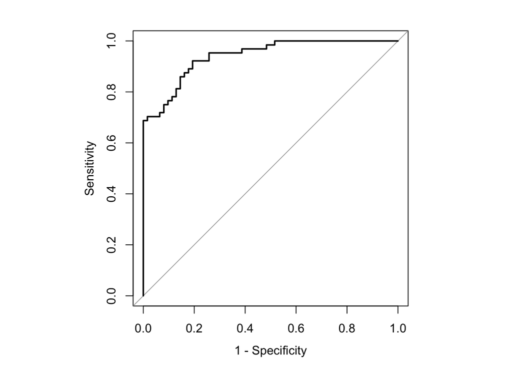

```
##
## Call:
## roc.default(response = test.Y, predictor = glm.probs, plot = TRUE,     legacy.axes = TRUE)
##
## Data: glm.probs in 62 controls (test.Y 0) < 64 cases (test.Y 1).
## Area under the curve: 0.941
```

```r
par(pty = "s")
roc(test.Y, glm.probs, plot = TRUE, legacy.axes = TRUE)
```

```r
cols_keep <- c("zn", "nox", "age", "dis", "rad", "tax", "ptratio", "lstat", "medv")
train <- train[, c(cols_keep, "crim01")]

train.X <- train.X[, cols_keep]
test.X  <- test.X[, cols_keep]
```

## LDA

The assumptions posed by LDA are a linear decision boundary, so hopes are not exactly high here.

```r
lda.fit <- lda(crim01 ~ zn + nox + dis + rad + tax, data = train)
lda.fit
```

```
## Call:
## lda(crim01 ~ zn + nox + dis + rad + tax, data = train)
##
## Prior probabilities of groups:
##         0         1
## 0.5026316 0.4973684
##
## Group means:
##          zn       nox      dis       rad      tax
## 0 21.643979 0.4695848 5.054677  4.157068 307.3037
## 1  1.079365 0.6363175 2.540708 14.968254 512.4550
##
## Coefficients of linear discriminants:
##              LD1
## zn  -0.006617237
## nox  8.619289781
## dis -0.041190992
## rad  0.090289784
## tax -0.001493576
```

Let’s measure accuracy:

```r
lda.pred <- predict(lda.fit, test.X)$class
confusionMatrix(factor(lda.pred), factor(test.Y))
```

```
## Confusion Matrix and Statistics
##
##           Reference
## Prediction  0  1
##          0 59 15
##          1  3 49
##
##                Accuracy : 0.8571
##                  95% CI : (0.7837, 0.9131)
##     No Information Rate : 0.5079
##     P-Value [Acc > NIR] : < 2.2e-16
##
##                   Kappa : 0.7151
##
##  Mcnemar's Test P-Value : 0.009522
##
##             Sensitivity : 0.9516
##             Specificity : 0.7656
##          Pos Pred Value : 0.7973
##          Neg Pred Value : 0.9423
##              Prevalence : 0.4921
##          Detection Rate : 0.4683
##    Detection Prevalence : 0.5873
##       Balanced Accuracy : 0.8586
##
##        'Positive' Class : 0
##
```

The LDA fit performs (better?) than logistic regression with an accuracy of 0.8571, a sensitivity of 0.9516 (very good) and a specificity of 0.7656 (not so good). Saying which is better depends on the context — which is better, sensitivity or specificity?

Yarrrr. (Pirate noise)

## Naive Bayes

```r
nb.fit <- naiveBayes(crim01 ~ zn + nox + dis + rad + tax, data = train)
nb.fit
```

```
##
## Naive Bayes Classifier for Discrete Predictors
##
## Call:
## naiveBayes.default(x = X, y = Y, laplace = laplace)
##
## A-priori probabilities:
## Y
##         0         1
## 0.5026316 0.4973684
##
## Conditional probabilities:
##    zn
## Y        [,1]      [,2]
##   0 21.643979 29.171074
##   1  1.079365  4.582465
##
##    nox
## Y        [,1]       [,2]
##   0 0.4695848 0.05581681
##   1 0.6363175 0.09963836
##
##    dis
## Y       [,1]     [,2]
##   0 5.054677 2.107221
##   1 2.540708 1.140221
##
##    rad
## Y        [,1]     [,2]
##   0  4.157068 1.706471
##   1 14.968254 9.547142
##
##    tax
## Y       [,1]      [,2]
##   0 307.3037  89.22716
##   1 512.4550 166.90816
```

Measure accuracy:

```r
nb.pred <- predict(nb.fit, test.X)
confusionMatrix(factor(nb.pred), factor(test.Y))
```

```
## Confusion Matrix and Statistics
##
##           Reference
## Prediction  0  1
##          0 55 15
##          1  7 49
##
##                Accuracy : 0.8254
##                  95% CI : (0.7477, 0.8872)
##     No Information Rate : 0.5079
##     P-Value [Acc > NIR] : 1.108e-13
##
##                   Kappa : 0.6514
##
##  Mcnemar's Test P-Value : 0.1356
##
##             Sensitivity : 0.8871
##             Specificity : 0.7656
##          Pos Pred Value : 0.7857
##          Neg Pred Value : 0.8750
##              Prevalence : 0.4921
##          Detection Rate : 0.4365
##    Detection Prevalence : 0.5556
##       Balanced Accuracy : 0.8264
##
##        'Positive' Class : 0
##
```

## KNN (yee-haw)

I’m not sure whether $n \gg p$ in this context but I have high hopes for kNN. 🤠 Let’s optimise $k$ immediately.

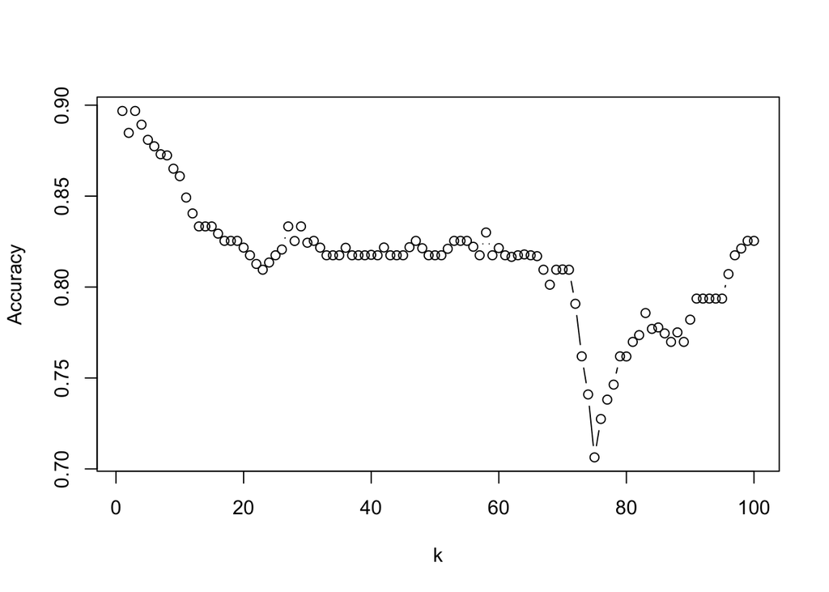

```r
ks <- sapply(1:100, function(k) {
  accs <- c()
  for (i in 1:100) {
    knn.pred <- knn(train.X, test.X, train.Y, k = k)
    cfm <- table(knn.pred, test.Y)
    acc <- (cfm[1,1] + cfm[2,2]) / (sum(cfm))
    accs <- append(accs, acc)
  }
  return(mean(accs))
})

plot(ks, type = "b", xlab = "k", ylab = "Accuracy")
```

Seems like $k = 1$ is optimal.

```r
k_opt <- which.max(ks)
k_opt
```

```
## [1] 1
```

Let’s grab some more statistics.

```r
knn.pred <- knn(train.X, test.X, train.Y, k = k_opt)
confusionMatrix(factor(knn.pred), factor(test.Y))
```

```
## Confusion Matrix and Statistics
##
##           Reference
## Prediction  0  1
##          0 54  5
##          1  8 59
##
##                Accuracy : 0.8968
##                  95% CI : (0.83, 0.9439)
##     No Information Rate : 0.5079
##     P-Value [Acc > NIR] : <2e-16
##
##                   Kappa : 0.7934
##
##  Mcnemar's Test P-Value : 0.5791
##
##             Sensitivity : 0.8710
##             Specificity : 0.9219
##          Pos Pred Value : 0.9153
##          Neg Pred Value : 0.8806
##              Prevalence : 0.4921
##          Detection Rate : 0.4286
##    Detection Prevalence : 0.4683
##       Balanced Accuracy : 0.8964
##
##        'Positive' Class : 0
##
```